# 분석프레임워크

Rose Koh

#### 1. 분석 프레임워크

- Set the objective of Analaysis
- Set Hypothesys
- Set Variables
- Set Analysis method
- Develop analysis data collection
- Analyze
- Interprete

#### 2. 분석목표설정

- 내가 궁금한것은 무엇인가?
- 상품수와 예약수의 관련성 검증.

#### 3. 가설수립

- 가설: 상품수가 늘어나면 예약수가 늘어날 것 이다.

#### 4. 변수 및 분석방법 선정 (어떤변수일때는 무슨 방법을 써야한다.)

- 측정변수: 상품수, 예약수
- 분석방법: 회귀분석
- 독립변수 (원인)와,종속변수 (결과) : 하지만 원인/결과라고 하지 않음
- 왜냐하면 상관관계와 인과관계가 같지 않음
- 비교하려는 집단 / 비교하려는 값

#### 5. 측정도구 개발 (데이터가 없다면..)

- 서베이 구성

#### 6. 데이터 수집

- 누구를 대상으로 어떻게 수집할 것 인가(대상, 방법, 수집처)

#### 7.통계분석 및 결과해석

# II. 실습

## III. 통계학방법

- 독립과 종속변수가 명목인지 연속인지에 따라 어떤분석을 써야하는지 판단한다.
- 명목변수 : factor var
- 연속변수 : continous var (숫자의 크기)

### 1) 집단비교하기 - 두집단의 % 를 비교하겠다.

- 카이검증 (두집단의 비율을 비교) : 종속과 독립변수가 모두 명목변수 일때 사용
- 여행지별 사람의 연봉이 더 높을것이다. (연봉 3000이하, 이상)
- 아시아를 여행하는 사람들
- 유럽을 여행하는 사람들
- 카이검증 적용이 가능
- 논리적으로 말이 되어야, 데이터도 수집이 가능

### 2) 집단 평균 비교 - 명목값이 아니라 수치를 비교하겠다.

- T 테스트 (두집단의 평균 비교) : 독립변수는 명목, 종속변수는 연속값
- 표준편차가 커질수록 평균에서 어느정도 떨어져있는지 알려줌
- T값은 집단간 차이가 커질수록 커지는데, T값에 대한 확률치를 P값으로..
- 아시아를 여행하는 사람들
- 유럽을 여행하는 사람들
- 유럽지역여행자의 여행예산 평균이 아시아지역 여행자의 여행예산 평균보다 높을것이다.

### 3) 변수간의 관계

- 회귀분석
- 독립/종속 변수가 둘다 연속변수
- 광고비가 증가할수록 예약수가 증가할것이다.
- 최소 30개, 무응답 제거하고 100개 ~ 150개.
- 실무 200, 논문 400
- 데이터가 많을수록 좋은건 아님
- 하지만 100개 이상부터는 그 수가 달라지진 않음
- 사례수가 많을수록 p 밸류는 작아진다
- p밸류 외에 다른것들도 봐야한다…

### 기타

- 아노바 - 다중변량분석
- 로지스틱회귀분석 - 독립이 연속 종속이 명목

### Regression Analysis

```r
#회귀분석
raw.02 <- read.csv("./data/02_reg.csv", header =T)
df.b <- raw.02
str(df.b)
```

```
## 'data.frame':    133 obs. of  3 variables:
##  $ id   : int  1 2 3 4 5 6 7 8 9 10 ...
##  $ skill: num  2.43 2.33 2.26 2.63 2.69 2.4 2.42 2.31 2.51 1.49 ...
##  $ sat  : num  2.6 2.8 3 3.6 3 2.8 3.2 3 3.4 2.8 ...
```

```r
summary(df.b)
```

```
##        id          skill            sat
##  Min.   :  1   Min.   :1.150   Min.   :1.000
##  1st Qu.: 34   1st Qu.:2.230   1st Qu.:2.200
##  Median : 67   Median :2.630   Median :2.800
##  Mean   : 67   Mean   :2.642   Mean   :2.838
##  3rd Qu.:100   3rd Qu.:3.050   3rd Qu.:3.600
##  Max.   :133   Max.   :5.000   Max.   :4.800
```

```r
#lm # linear method
out.reg <- lm(data = df.b, sat~skill)
summary(out.reg) #summary를 이용해야 회귀분석 결과값이 출력됨.
```

```
##
## Call:
## lm(formula = sat ~ skill, data = df.b)
##
## Residuals:
##      Min       1Q   Median       3Q      Max
## -2.13148 -0.56882  0.03762  0.60350  2.09034
##
## Coefficients:
##             Estimate Std. Error t value Pr(>|t|)
## (Intercept)   2.0180     0.2840   7.106 6.89e-11 ***
## skill         0.3102     0.1038   2.989  0.00334 **
## ---
## Signif. codes:  0 '***' 0.001 '**' 0.01 '*' 0.05 '.' 0.1 ' ' 1
##
## Residual standard error: 0.8538 on 131 degrees of freedom
## Multiple R-squared:  0.06386,    Adjusted R-squared:  0.05672
## F-statistic: 8.937 on 1 and 131 DF,  p-value: 0.003339
```

```r
# coefficients:
# Intercept 상수
# Estimate: 회귀계수 B
# p가 0.003 0.05보다 작으니, 유의함
# r스퀘어 : multiple R-squared
library(ztable)
```

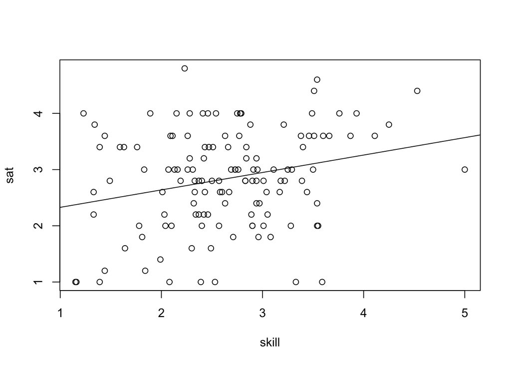

```r
ztable(out.reg)
# excel에 ctrl+alt+v로 텍스트로 붙이면 형식이 꺠지지않고 복사가 잘됨!


#간단한그래프
plot(data = df.b, sat~ skill) # 산점도
abline(out.reg) #회귀선 추가
```

### T-Test

```r
library(foreign)
library(ggplot2)
#성별과 소득의 차이

raw.03 <- read.spss("./data/data_spss_Koweps2014.sav", to.data.frame = T)
df.c <- raw.03

dim(df.c)
```

```
## [1] 7048 1081
```

```r
str(df.c, list.len = 10)
```

```
## 'data.frame':    7048 obs. of  1081 variables:
##  $ h09_id      : num  1 2 3 4 6 7 8 10 12 14 ...
##  $ h09_ind     : num  1 1 1 1 1 1 1 1 1 1 ...
##  $ h09_sn      : num  1 1 1 1 1 1 1 1 1 1 ...
##  $ h09_merkey  : num  10101 20101 30101 40101 60101 ...
##  $ h_new       : num  0 0 0 0 0 0 0 0 0 0 ...
##  $ h09_cobf    : num  NA NA NA NA NA NA NA NA NA NA ...
##  $ h09_ws      : num  0.372 0.517 0.607 0.357 0.465 ...
##  $ h09_wg      : num  962 1337 1569 922 1202 ...
##  $ h09_reg5    : num  1 1 1 1 1 4 1 1 1 1 ...
##  $ h09_reg7    : num  1 1 1 1 1 7 1 1 1 1 ...
##   [list output truncated]
##  - attr(*, "variable.labels")= Named chr  "\260\241\261\270 \306\320\263\316 ID(h09_id)" "\260\241\261\270\273\375\274\272\302\367\274\366(h09_ind)" "\260\241\261\270\272\320\270\256\300\317\267\303\271\370\310\243(h09_sn)" "\306\320\263\316\260\243 \260\241\261\270\270\323\301\366 \305\260\272\2…
##   ..- attr(*, "names")= chr  "h09_id" "h09_ind" "h09_sn" "h09_merkey" ...
```

```r
df.c$sex <- df.c$h0901_4
df.c$income <- df.c$h09_din

class(df.c$sex)
```

```
## [1] "numeric"
```

```r
summary(df.c$sex)
```

```
##    Min. 1st Qu.  Median    Mean 3rd Qu.    Max.
##   1.000   1.000   1.000   1.309   2.000   2.000
```

```r
table(df.c$sex)
```

```
##
##    1    2
## 4873 2175
```

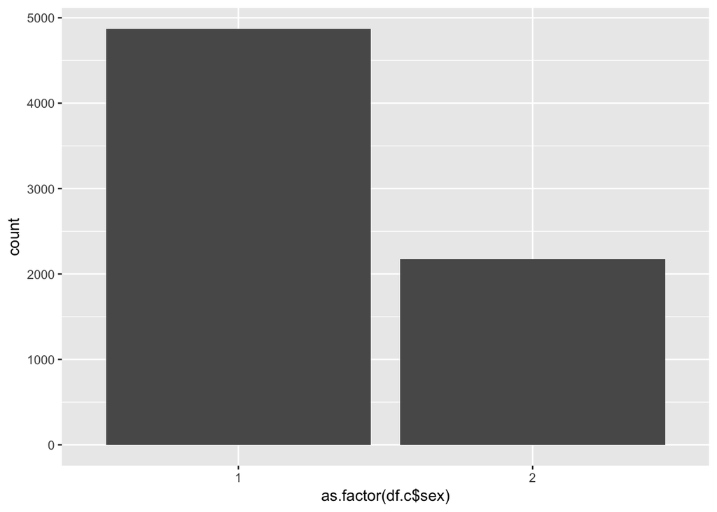

```r
qplot(as.factor(df.c$sex))
```

```r
table(is.na(df.c$sex))
```

```
##
## FALSE
##  7048
```

```r
df.c$sex <- ifelse(df.c$sex == 9, NA, df.c$sex)
table(df.c$sex)
```

```
##
##    1    2
## 4873 2175
```

```r
df.c$sex <- ifelse(df.c$sex ==1, "m",
                   ifelse(df.c$sex ==2, "f",
                          df.c$sex))
table(df.c$sex)
```

```
##
##    f    m
## 2175 4873
```

```r
#

class(df.c$income)
```

```
## [1] "numeric"
```

```r
summary(df.c$income)
```

```
##    Min. 1st Qu.  Median    Mean 3rd Qu.    Max.
##  -20516    1108    2404    3336    4642  108888
```

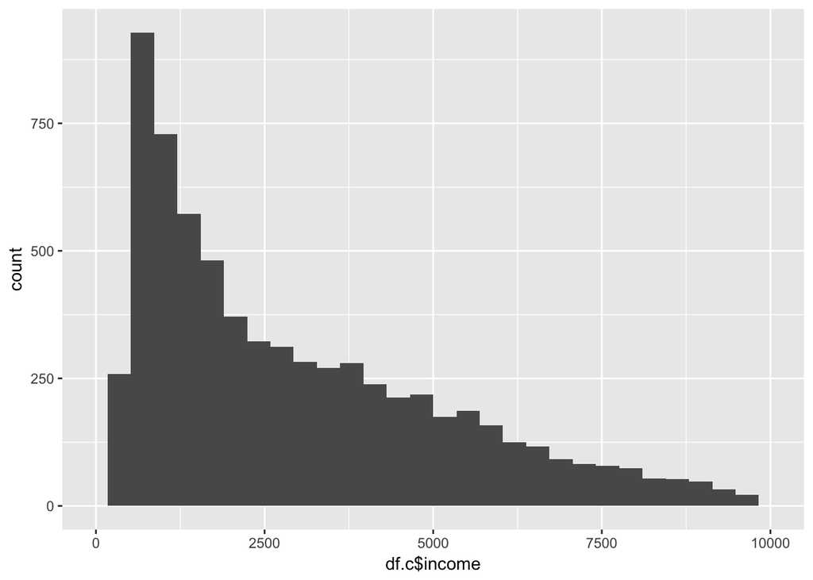

```r
qplot(df.c$income) + xlim(0,10000)
```

```r
table(is.na(df.c$income))
```

```
##
## FALSE
##  7048
```

```r
#
# 1. 기술통계표 만들기
# 성별 |사례수 | 평균 | 표준편차
library(dplyr)
tab.sex <- df.c %>%
        group_by(sex) %>%
        summarise(N = n(),
                  M = round(mean(income),2),
                  SD = round(sd(income),2)
        )
tab.sex
```

| sex | N | M | SD |
| --- | --- | --- | --- |
| f | 2175 | 1581.25 | 2103.14 |
| m | 4873 | 4118.90 | 3870.89 |

```r
write.csv(tab.sex, "tab_sex.csv")

#

t.test(data = df.c,
        income ~ sex,
        var.equal = T)
```

```
##
##  Two Sample t-test
##
## data:  income by sex
## t = -28.738, df = 7046, p-value < 2.2e-16
## alternative hypothesis: true difference in means is not equal to 0
## 95 percent confidence interval:
##  -2710.746 -2364.551
## sample estimates:
## mean in group f mean in group m
##        1581.255        4118.903
```

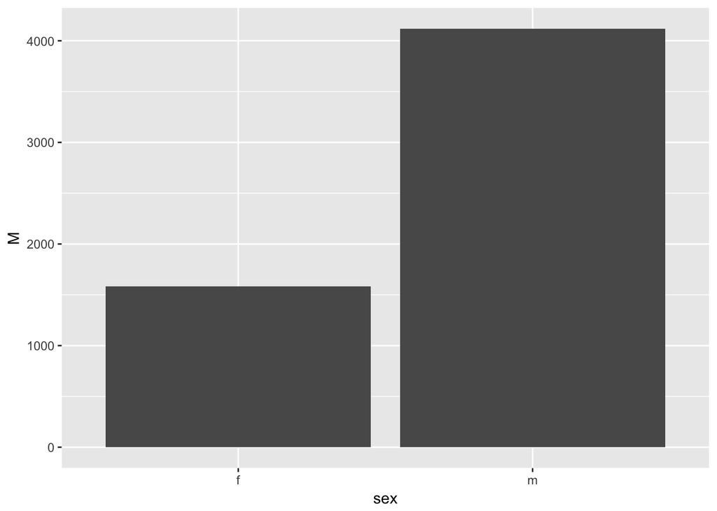

```r
# 두집단간의 차이가 통계적으로 유의미함 ( p-value)

ggplot(data = tab.sex, aes(sex,M)) +
        geom_bar(stat= "identity")
```

```r
# 1. 분석 목표
# 집의점유형태, 태어난년도 (1900~2013)

# 2. 가설
# 자가 / 전세,보증부월세,월세
# 집의점유형태가 자가 인 그룹의 태생년도수가 1970이하가 더 많을것이다.

# 3. 변수 및 분석방법

# 집의점유형태: 자가, 전세, 보증부월세, 월세 선택
# 년도수: 본인의 태생년도 기입

# 분석방법: 티테스트
# - T 테스트 (두집단의 평균 비교) : 독립변수는 명목, 종속변수는 연속값
# 표준편차가 커질수록 평균에서 어느정도 떨어져있는지 알려주는데
# - T값은 집단간 차이가 커질수록 커지는데, T값에 대한 확률치를 P값으로..

# 4. 측정도구
# 집의점유형태: 자가, 전세, 보증부월세, 월세 선택
# 년도수: 본인의 태생년도 기입

# 변수명   변수설명    문항내용    Range   SYSMIS, 모름/무응답  변수 종류
# h0906_3   집의 점유형태 1.자가   2.전세   3.보증부월세   4.월세(사글세)  5.기타 N(1~5)  모름/무응답=9    명목
# h0901_5   태어난 연도  년   N(1900~2013)    모름/무응답=9999 연속

raw.03 <- read.spss("./data/data_spss_Koweps2014.sav", to.data.frame = T)
df.d <- raw.03
str(df.d)
```

```
## 'data.frame':    7048 obs. of  1081 variables:
##  $ h09_id      : num  1 2 3 4 6 7 8 10 12 14 ...
##  $ h09_ind     : num  1 1 1 1 1 1 1 1 1 1 ...
##  $ h09_sn      : num  1 1 1 1 1 1 1 1 1 1 ...
##  $ h09_merkey  : num  10101 20101 30101 40101 60101 ...
##  $ h_new       : num  0 0 0 0 0 0 0 0 0 0 ...
##  $ h09_cobf    : num  NA NA NA NA NA NA NA NA NA NA ...
##  $ h09_ws      : num  0.372 0.517 0.607 0.357 0.465 ...
##  $ h09_wg      : num  962 1337 1569 922 1202 ...
##  $ h09_reg5    : num  1 1 1 1 1 4 1 1 1 1 ...
##  $ h09_reg7    : num  1 1 1 1 1 7 1 1 1 1 ...
##  $ h09_din     : num  2172 1675 1523 3842 3983 ...
##  $ h09_cin     : num  2208 2023 1571 3878 4079 ...
##  $ h09_flag    : num  0 0 0 0 0 0 0 0 0 0 ...
##  $ h09_hc      : num  1 1 1 1 1 2 2 2 2 2 ...
```

[output cut: 88 more lines]

```r
summary(df.d)
```

[output not shown]

[output cut: 2121 more lines]

[output not shown]

```r
df.d$homestatus <- df.d$h0906_3
df.d$birthyear <- df.d$h0901_5

table(df.d$homestatus)
```

```
##
##    1    2    3    4    5
## 3998  900 1184  150  816
```

```r
df.d$homestatus <- ifelse(df.d$homestatus == 1, "Y", "N")

relHomeBirth <- df.d %>%
        group_by(homestatus) %>%
        summarise(N = n(),
                  M = round(mean(birthyear),2),
                  SD = round(sd(birthyear),2)
        )
relHomeBirth
```

| homestatus | N | M | SD |
| --- | --- | --- | --- |
| N | 3050 | 1955.16 | 17.28 |
| Y | 3998 | 1951.34 | 14.27 |

```r
write.csv(relHomeBirth, "relHomeBirth.csv")

#t-test
#종속변수 ~ 독립변수
t.test(data = df.d,
       birthyear~homestatus,
       var.equal = T)
```

```
##
##  Two Sample t-test
##
## data:  birthyear by homestatus
## t = 10.156, df = 7046, p-value < 2.2e-16
## alternative hypothesis: true difference in means is not equal to 0
## 95 percent confidence interval:
##  3.083354 4.558306
## sample estimates:
## mean in group N mean in group Y
##        1955.160        1951.339
```

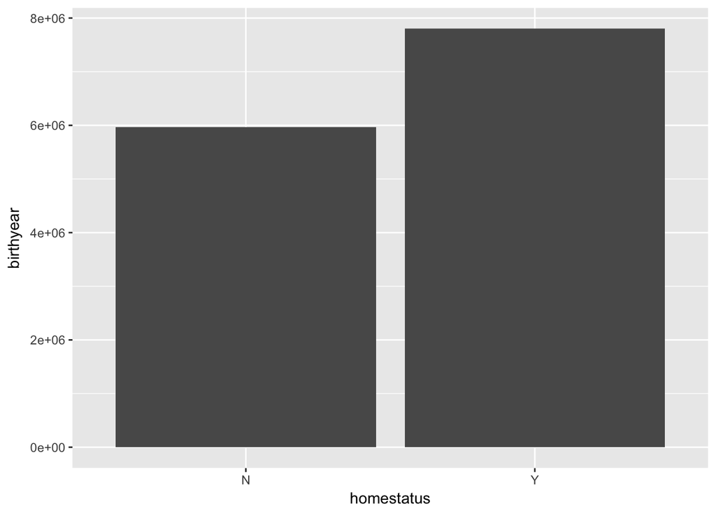

```r
# Two Sample t-test
#
# data:  birthyear by homestatus
# t = 10.156, df = 7046, p-value < 2.2e-16

# alternative hypothesis: true difference in means is not equal to 0
# 95 percent confidence interval:
#         3.083354 4.558306

# sample estimates:
#         mean in group N mean in group Y
# 1955.160        1951.339


ggplot(data = df.d,
       aes(x = homestatus, y = birthyear)) + geom_bar(stat="identity")
```

#### Regression

```r
# 1. 분석 목표  가구원수와 주거면적의 관계
# 2. 가설 가구원수가 많을수록 주거면적도 높을것이다.
# 3. 변수 및 분석방법  가구원수: 가구원수가 몇명인지 선택
# 주거면적: 살고있는 집의 평수 기입
# 분석방법: 회귀분석
# 4. 측정도구   가구원수: 가구원수가 몇명인지 선택
# 주거면적: 살고있는 집의 평수 기입

# h0901_1   가구원수    명   N(1~9)  모름/무응답=99
# h0906_5   주거면적    주거면적(평방미터) -소수점 첫째자리에서 반올림  N(0~9998)   모름/무응답=9999


raw.03 <- read.spss("./data/data_spss_Koweps2014.sav", to.data.frame = T)
df.c <- raw.03
str(df.c)
```

```
## 'data.frame':    7048 obs. of  1081 variables:
##  $ h09_id      : num  1 2 3 4 6 7 8 10 12 14 ...
##  $ h09_ind     : num  1 1 1 1 1 1 1 1 1 1 ...
##  $ h09_sn      : num  1 1 1 1 1 1 1 1 1 1 ...
##  $ h09_merkey  : num  10101 20101 30101 40101 60101 ...
##  $ h_new       : num  0 0 0 0 0 0 0 0 0 0 ...
##  $ h09_cobf    : num  NA NA NA NA NA NA NA NA NA NA ...
##  $ h09_ws      : num  0.372 0.517 0.607 0.357 0.465 ...
##  $ h09_wg      : num  962 1337 1569 922 1202 ...
##  $ h09_reg5    : num  1 1 1 1 1 4 1 1 1 1 ...
##  $ h09_reg7    : num  1 1 1 1 1 7 1 1 1 1 ...
##  $ h09_din     : num  2172 1675 1523 3842 3983 ...
##  $ h09_cin     : num  2208 2023 1571 3878 4079 ...
##  $ h09_flag    : num  0 0 0 0 0 0 0 0 0 0 ...
##  $ h09_hc      : num  1 1 1 1 1 2 2 2 2 2 ...
```

[output cut: 88 more lines]

```r
summary(df.c)
```

[output not shown]

[output cut: 2121 more lines]

[output not shown]

```r
df.c$members <- df.c$h0901_1
df.c$sqm <- df.c$h0906_5

table(is.na(df.c$members))
```

```
##
## FALSE
##  7048
```

```r
table(is.na(df.c$sqm))
```

```
##
## FALSE
##  7048
```

```r
class(df.c$members)
```

```
## [1] "numeric"
```

```r
class(df.c$sqm)
```

```
## [1] "numeric"
```

```r
summary(df.c$members)
```

```
##    Min. 1st Qu.  Median    Mean 3rd Qu.    Max.
##   1.000   1.000   2.000   2.431   3.000   8.000
```

```r
summary(df.c$sqm)
```

```
##    Min. 1st Qu.  Median    Mean 3rd Qu.    Max.
##    7.00   53.00   76.00   75.54   99.00  495.00
```

```r
table(df.c$members)
```

```
##
##    1    2    3    4    5    6    7    8
## 1990 2237 1187 1192  334   88   17    3
```

```r
table(df.c$sqm)
```

```
##
##   7  10  13  16  20  23  26  30  33  36  40  43  46  50  53  56  59  63
##   6  20  30  65  53  66 111  43 225  59 284 205  59 477  96 222 394 141
##  66  69  73  76  79  82  86  89  92  96  99 102 106 108 109 112 116 119
## 616 161 176 195 454 605 139 124 167  57 438 132 340   1 214 146  91  32
## 122 125 129 132 135 139 142 145 148 152 155 158 162 165 168 172 175 178
##  21  46  16  68  11  20  20   9  37   7  12  17   6  42   2   5   3   4
## 182 185 188 191 195 198 208 211 214 221 228 231 241 264 297 330 412 495
##   5   4   2   4   7  13   2   1   3   1   1   4   1   3   1   3   1   2
```

```r
result <- lm(data = df.c, sqm~members)
summary(result)
```

```
##
## Call:
## lm(formula = sqm ~ members, data = df.c)
##
## Residuals:
##    Min     1Q Median     3Q    Max
## -81.73 -21.65  -3.63  16.60 414.33
##
## Coefficients:
##             Estimate Std. Error t value Pr(>|t|)
## (Intercept)  53.6092     0.7821   68.54   <2e-16 ***
## members       9.0202     0.2846   31.70   <2e-16 ***
## ---
## Signif. codes:  0 '***' 0.001 '**' 0.01 '*' 0.05 '.' 0.1 ' ' 1
##
## Residual standard error: 30.63 on 7046 degrees of freedom
## Multiple R-squared:  0.1248, Adjusted R-squared:  0.1247
## F-statistic:  1005 on 1 and 7046 DF,  p-value: < 2.2e-16
```

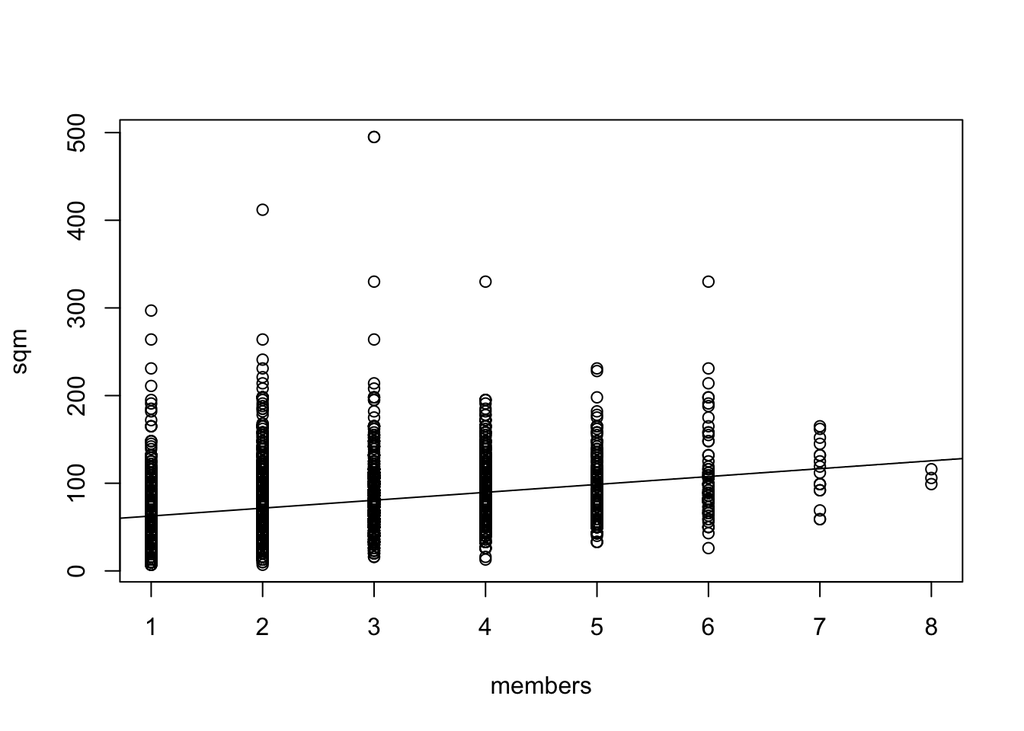

```r
ztable(result)


#               Estimate    Std. Error  t value         Pr(>|t|)
# (Intercept)   53.6092         0.7821          68.54           0.0000
# members   9.0202          0.2846          31.70           0.0000
# Call: lm(formula = sqm ~ members, data = df.c)

# 가구원이 1명 증가할때 9sqm 가 증가

plot(data = df.c, sqm~members) # 산점도
abline(result)
```

```r
# 1. 분석 목표
# 태어난년도, 금융기관대출

# 2. 가설
# 태어난년도가 최근일수록 대출액수가 더 높을것이다.

# 3. 변수 및 분석방법

# 태어난년도기입
# 대출액수기입

# 분석방법: 회귀분석

# 4. 측정도구
# 태어난년도기입
# 대출액수기입


# 변수명   변수설명    문항내용    Range   SYSMIS, 모름/무응답  변수 종류
# h0901_5   태어난 연도  년   N(1900~2013)    모름/무응답=9999 연속
# h0909_aq1 금융기관대출  연간 부채액(단위: 만원)  N(0~9999998)    "없음=0
# 모름/무응답=9999999"   연속

raw.03 <- read.spss("./data/data_spss_Koweps2014.sav", to.data.frame = T)
df.d <- raw.03
str(df.d)
```

```
## 'data.frame':    7048 obs. of  1081 variables:
##  $ h09_id      : num  1 2 3 4 6 7 8 10 12 14 ...
##  $ h09_ind     : num  1 1 1 1 1 1 1 1 1 1 ...
##  $ h09_sn      : num  1 1 1 1 1 1 1 1 1 1 ...
##  $ h09_merkey  : num  10101 20101 30101 40101 60101 ...
##  $ h_new       : num  0 0 0 0 0 0 0 0 0 0 ...
##  $ h09_cobf    : num  NA NA NA NA NA NA NA NA NA NA ...
##  $ h09_ws      : num  0.372 0.517 0.607 0.357 0.465 ...
##  $ h09_wg      : num  962 1337 1569 922 1202 ...
##  $ h09_reg5    : num  1 1 1 1 1 4 1 1 1 1 ...
##  $ h09_reg7    : num  1 1 1 1 1 7 1 1 1 1 ...
##  $ h09_din     : num  2172 1675 1523 3842 3983 ...
##  $ h09_cin     : num  2208 2023 1571 3878 4079 ...
##  $ h09_flag    : num  0 0 0 0 0 0 0 0 0 0 ...
##  $ h09_hc      : num  1 1 1 1 1 2 2 2 2 2 ...
```

[output cut: 88 more lines]

```r
summary(df.d)
```

[output not shown]

[output cut: 2121 more lines]

[output not shown]

```r
df.d$loan <- df.d$h0909_aq1
df.d$birthyear <- df.d$h0901_5

table(df.d$loan)
```

```
##
##       0       2      10      25      30      40      50      60      65
##    5078       1       1       1       2       2       2       2       1
##      70      75      80      99     100     105     114     120     150
##       1       1       1       1      14       1       1       1       2
##     160     170     180     200     210     240     250     260     270
##       3       2       2      32       1       1       4       1       1
##     280     300     320     326     327     336     339     340     350
##       1      42       3       1       1       1       1       2       3
##     384     390     396     400     420     425     430     450     460
##       1       1       1      27       2       1       1       7       2
##     470     480     483     500     524     540     550     560     565
##       1       1       1      71       1       1       3       2       1
##     570     580     590     600     650     670     675     680     690
##       1       1       1      34       3       1       1       1       1
```

[output cut: 78 more lines]

```r
table(df.d$birthyear)
```

```
##
## 1918 1919 1920 1921 1922 1923 1924 1925 1926 1927 1928 1929 1930 1931 1932
##    1    2    2    8   13   13   14   23   24   35   49   56   79  107  134
## 1933 1934 1935 1936 1937 1938 1939 1940 1941 1942 1943 1944 1945 1946 1947
##  116  145  178  183  186  197  192  188  176  235  173  141  126  136  161
## 1948 1949 1950 1951 1952 1953 1954 1955 1956 1957 1958 1959 1960 1961 1962
##  103  110  104   94  141  107  109  118  124  125  107  129  153  125  130
## 1963 1964 1965 1966 1967 1968 1969 1970 1971 1972 1973 1974 1975 1976 1977
##  124  114  121   99  113  114  123  129  131  114  110  121  110   95   72
## 1978 1979 1980 1981 1982 1983 1984 1985 1986 1987 1988 1989 1990 1991 1992
##   76   85   67   55   51   44   20   23   18    9   10    7    2    7    4
## 1993 1994 1995 2002
##    2    3    2    1
```

```r
summary(df.d$loan)
```

```
##    Min. 1st Qu.  Median    Mean 3rd Qu.    Max.
##       0       0       0    4264     500 9999999
```

```r
summary(df.d$birthyear)
```

```
##    Min. 1st Qu.  Median    Mean 3rd Qu.    Max.
##    1918    1940    1952    1953    1966    2002
```

```r
table(is.na(df.d$loan))
```

```
##
## FALSE
##  7048
```

```r
table(is.na(df.d$birthyear))
```

```
##
## FALSE
##  7048
```

```r
class(df.d$loan)
```

```
## [1] "numeric"
```

```r
class(df.d$birthyear)
```

```
## [1] "numeric"
```

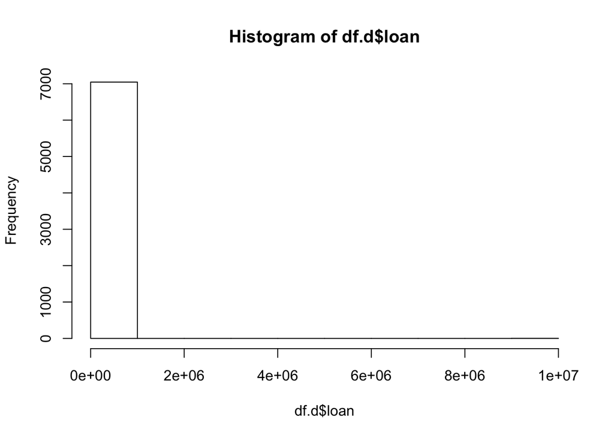

```r
hist(df.d$loan)
```

```r
dfloannew <- df.d %>% filter(loan > 0)
table(dfloannew$loan)
```

```
##
##       2      10      25      30      40      50      60      65      70
##       1       1       1       2       2       2       2       1       1
##      75      80      99     100     105     114     120     150     160
##       1       1       1      14       1       1       1       2       3
##     170     180     200     210     240     250     260     270     280
##       2       2      32       1       1       4       1       1       1
##     300     320     326     327     336     339     340     350     384
##      42       3       1       1       1       1       2       3       1
##     390     396     400     420     425     430     450     460     470
##       1       1      27       2       1       1       7       2       1
##     480     483     500     524     540     550     560     565     570
##       1       1      71       1       1       3       2       1       1
##     580     590     600     650     670     675     680     690     700
##       1       1      34       3       1       1       1       1      28
```

[output cut: 78 more lines]

```r
result2 <- lm(data = dfloannew, loan~birthyear)
summary(result2)
```

```
##
## Call:
## lm(formula = loan ~ birthyear, data = dfloannew)
##
## Residuals:
##     Min      1Q  Median      3Q     Max
##  -20554  -14439  -11765   -8157 9984625
##
## Coefficients:
##              Estimate Std. Error t value Pr(>|t|)
## (Intercept)  341111.8  1051758.3   0.324    0.746
## birthyear      -166.2      536.4  -0.310    0.757
##
## Residual standard error: 318500 on 1968 degrees of freedom
## Multiple R-squared:  4.877e-05,  Adjusted R-squared:  -0.0004593
## F-statistic: 0.09599 on 1 and 1968 DF,  p-value: 0.7567
```

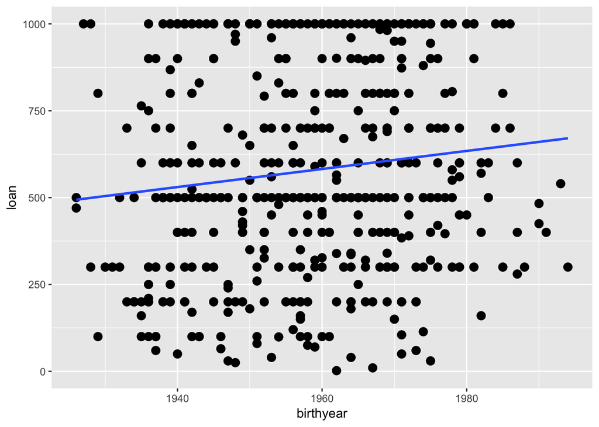

```r
ztable(result2)

ggplot(dfloannew, aes(birthyear, loan)) +
        ylim(1,1000) +
        geom_point(size = 3) +
        geom_smooth(method = lm,
                    se = F)
```

```r
# 이럴때는 그룹으로 나눠서 티테스트를 해보는것도 좋음.
# 몇년전이면 A 그룹, 아니면 B 그룹으로 묶어서.
```